# chapter3.Rmd

Ella

7 helmikuuta 2017

```r
library(tidyr); library(dplyr); library(ggplot2); library(boot)
```

# 3. Logistic Regression

### Task 2. Brief summary of the data

Here I will present the new data, that consists of background information about the student and some personal questions regarding their life as a whole. But the variables I will be focusing on mostly in this task is ‘alc_use’ and ‘high_use’. But firstly I shall present all the variables:

```r
url <- read.table("http://s3.amazonaws.com/assets.datacamp.com/production/course_2218/datasets/alc.txt", sep=",", header=TRUE)
```

```r
str(url)
```

```
## 'data.frame':    382 obs. of  35 variables:
##  $ school    : Factor w/ 2 levels "GP","MS": 1 1 1 1 1 1 1 1 1 1 ...
##  $ sex       : Factor w/ 2 levels "F","M": 1 1 1 1 1 2 2 1 2 2 ...
##  $ age       : int  18 17 15 15 16 16 16 17 15 15 ...
##  $ address   : Factor w/ 2 levels "R","U": 2 2 2 2 2 2 2 2 2 2 ...
##  $ famsize   : Factor w/ 2 levels "GT3","LE3": 1 1 2 1 1 2 2 1 2 1 ...
##  $ Pstatus   : Factor w/ 2 levels "A","T": 1 2 2 2 2 2 2 1 1 2 ...
##  $ Medu      : int  4 1 1 4 3 4 2 4 3 3 ...
##  $ Fedu      : int  4 1 1 2 3 3 2 4 2 4 ...
##  $ Mjob      : Factor w/ 5 levels "at_home","health",..: 1 1 1 2 3 4 3 3 4 3 ...
##  $ Fjob      : Factor w/ 5 levels "at_home","health",..: 5 3 3 4 3 3 3 5 3 3 ...
##  $ reason    : Factor w/ 4 levels "course","home",..: 1 1 3 2 2 4 2 2 2 2 ...
##  $ nursery   : Factor w/ 2 levels "no","yes": 2 1 2 2 2 2 2 2 2 2 ...
##  $ internet  : Factor w/ 2 levels "no","yes": 1 2 2 2 1 2 2 1 2 2 ...
##  $ guardian  : Factor w/ 3 levels "father","mother",..: 2 1 2 2 1 2 2 2 2 2 ...
```

[output cut: 21 more lines]

Here I also want to present the dimensions of the data:

```r
dim(url)
```

```
## [1] 382  35
```

As we can see, there are 35 different variables and 382 observations.

```r
library(tidyr); library(dplyr); library(ggplot2)
```

## Task 3. Numerical and graphical exploring variables

### Alcohol consumption variables

The two new variables I will be studying the relationship with other variables are alc_use and high_use. These variables consists of other variables combined. Alc_use consists of the avergage of the variables Dalc and Walc, that are the variables that measure how much alcohol is consumed during the workweek and the weekends. The high_use is when the alc_use on avreage is over 2.

#### Tables and visuals of the variable alc_use

```r
table(url$alc_use)
```

```
##
##   1 1.5   2 2.5   3 3.5   4 4.5   5
## 144  68  58  42  32  17   9   3   9
```

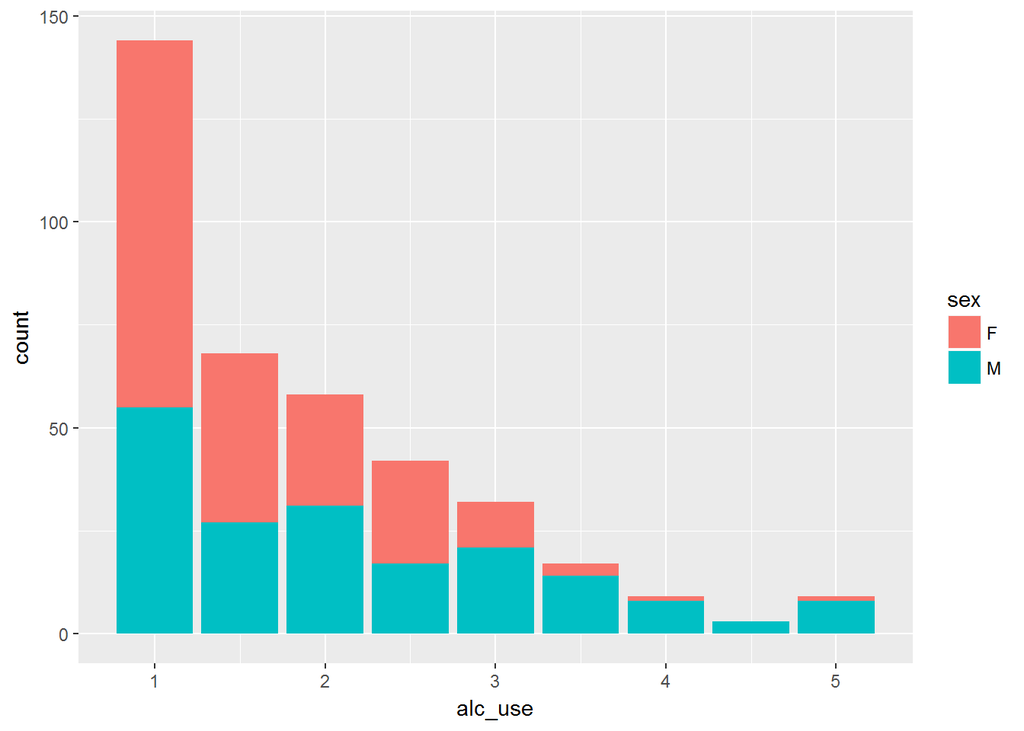

```r
g7 <- ggplot(data = url, aes(x = alc_use, fill = sex))
g7 + geom_bar()
```

The alc use variable is clearly distributed mostly on the left side, which means that the alcohol consumption is smaller. The most common value in this variable is 1. It is very interesting that the proportion of women are larger in the values 1 and 1.5, and when the value is 3 or larger, men has the higher proportion. In other words I conclude that men consume more alcohol than women.

#### Tables and visuals of the variable high_use

```r
table(url$high_use)
```

```
##
## FALSE  TRUE
##   270   112
```

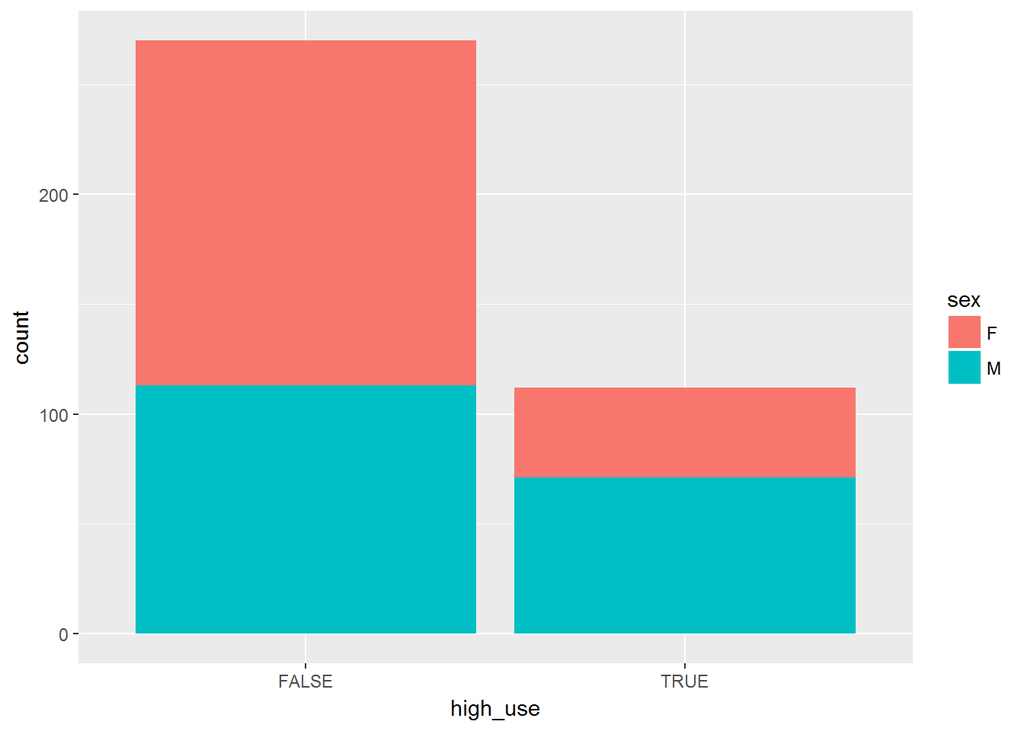

```r
g8 <- ggplot(data = url, aes(x = high_use, fill = sex))
g8 + geom_bar()
```

The distribution supports my previous assumptions regarding the gender difference in alcohol consumption. Here we can see that in the FALSE group (=<2), has a majority of women. On the other hand, the TRUE group has a majority of men. This was not an unexpeced result, because alc_use and high_use use the same variables and data.

## 4 interesting variables

The first variable is ‘failures’, this variable measures how many times the individual has failed from a scale from 0-3 and more than 4. I think high use of alcohol could lead to a higher rate of failure in school. This bases on the hypothesis that alcohol consumption could lead to less success in school.

The third variable is ‘famrel’ that measures the quality of the relationship with the family. This variable ranges from 1-5, where 1 is very bad, and 5 is excellent.

The forth variable ‘goout’ that measures the respondents opinion on how often he/she goes out with friends on a scale from 1-5, where 1 equals very low, 5 equals very high.

### Tables and visuals of the variable failures

```r
table(url$failures)
```

```
##
##   0   1   2   3
## 316  38  11  17
```

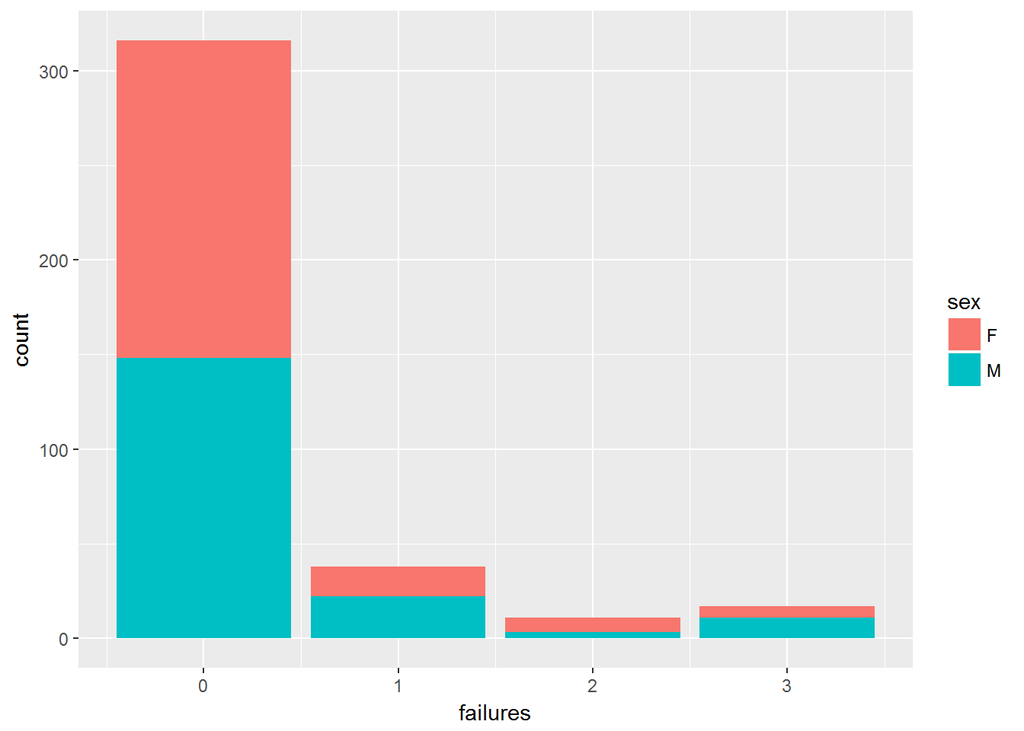

```r
g3 <- ggplot(data = url, aes(x = failures, fill = sex))
g3 + geom_bar()
```

From this table we can see how many failures in tests individuals has made, and also explore the difference between the genders.

In the first value 0, there is no significant difference between the genders, and we can also conclude that this is the most common value in this variable (316). But there are slight differences between the values 1,2 and 3, but I am unsurtain if they are significant or not.

*hypothesis* My hypothesis regarding the amount of faliures and alcohol use, is that the higher the failure rate is ,the higher is the alcohol consumption. In other words, I think there will be a correlation between high use of alcohol and high amount of failures. I base my hypothesis on the fact that large amounts of alcohol could have a negative effect on school grades/failures.

### Tables and visuals of the variable absences

```r
table(url$absences)
```

```
##
##   0   1   2   3   4   5   6   7   8   9  10  11  12  13  14  15  16  17
## 116   3  67   6  51   4  30   8  21   3  17   2  10   3  11   3   6   1
##  18  19  20  21  22  23  24  25  26  28  30  54  56  75
##   4   1   2   1   3   1   1   1   1   1   1   1   1   1
```

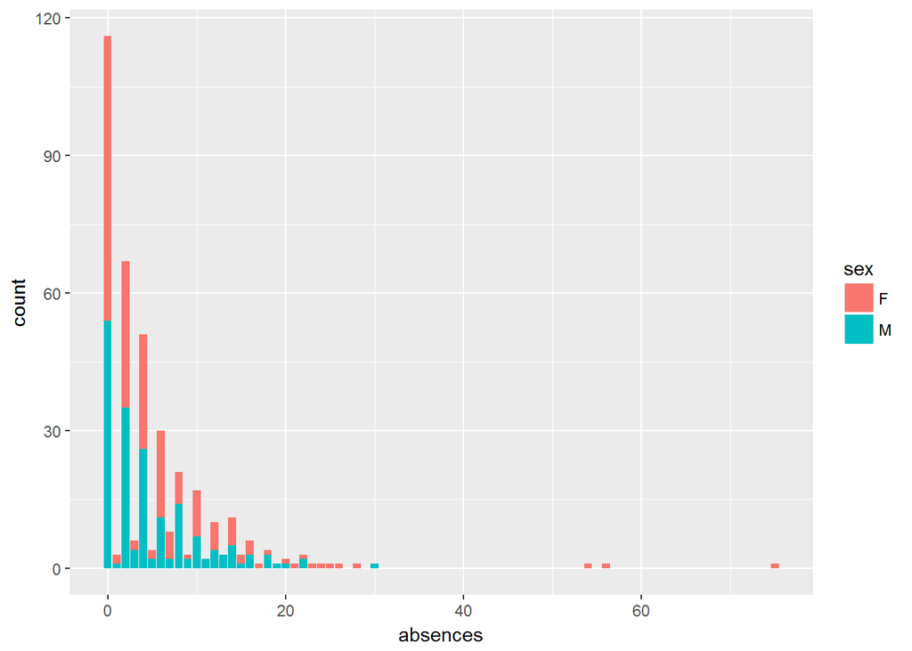

```r
g4 <- ggplot(data = url, aes(x = absences, fill = sex))
g4 + geom_bar()
```

The distribution of absences are slightly odd, but I assume that this depends on 2h lectures. The distribution (beginning from the left) every other value is high and low. If we look at the table frame from this variable, we can conclude the same thing. From this distribution it seems that women tend to be more absent from school in comparison to men. The extreme values 54, 56 and 75 are also absences of women.

*hypothesis* The hypotheis regarding the variable absences, is that the more frequantley an individual is absent from school, the more alcohol this individual uses. The hypothesis is not based upon theoretical facts, only on subjective opinions. Some of the individuals might be absent due to excessive use of alcohol.

### Tables and visuals of the variable famrel

```r
table(url$famrel)
```

```
##
##   1   2   3   4   5
##   9  18  66 183 106
```

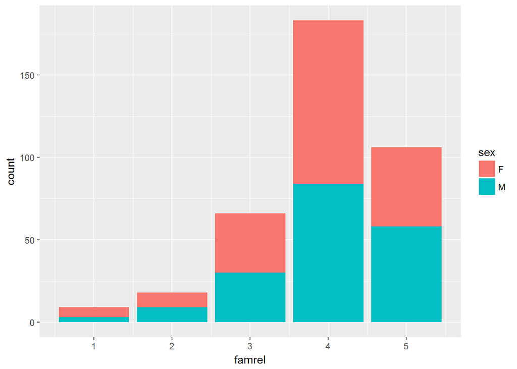

```r
g5 <- ggplot(data = url, aes(x = famrel, fill = sex))
g5 + geom_bar()
```

The variable that measure the family relationship from a scale from 1-5(very bad - excellent), we can see that the distribution is on the most part between 3 and 5. We can conclude that most of the respondents have between a neutral and an excellent relationship with their families.

*hypothesis* The hypothesis regarding he variable that measures the family relationship and alcohol consumption, is that hte better the relationship with the family (3<) the less the individuals consume alcohol, or is a high user of alcohol. My hypotheis is based upon the idea, that high use of alcohol could be a cause of bad relations to people that are important to the respondents. So to conclude, my hypothesis is that high values on famrel will correlate to low values of alcohol consumption.

### Tables and visuals of the variable goout

```r
table(url$goout)
```

```
##
##   1   2   3   4   5
##  24  99 123  82  54
```

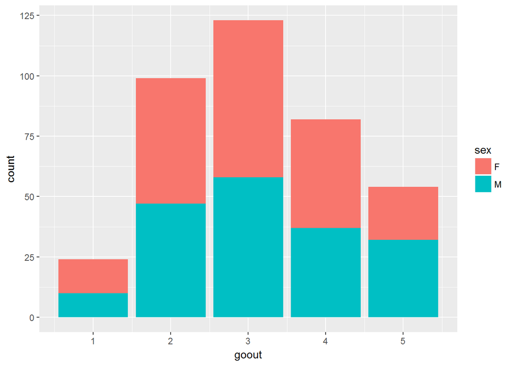

```r
g6 <- ggplot(data = url, aes(x = goout, fill = sex))
g6 + geom_bar()
```

The variable goout measures going out with friends, on a scale from very low(1) to very high(5). Most of the distribution is between the values 2-4, and only a few find themselves spenfinf very low amount of time going out with friends. There is neither a very big difference between the genders.

*hypothesis* The hypothesis to this variable that measures going out with friends and alcohol consumption, is that a high value on the goout could correlate with higher use of alcohol. This hypothesis is based upon my opinion that in group settings it is easier to consume alcohol, in comparison not going out with friend and drinking alcohol alone.

## Exploring the relationships between the variables

### High_use vs absences

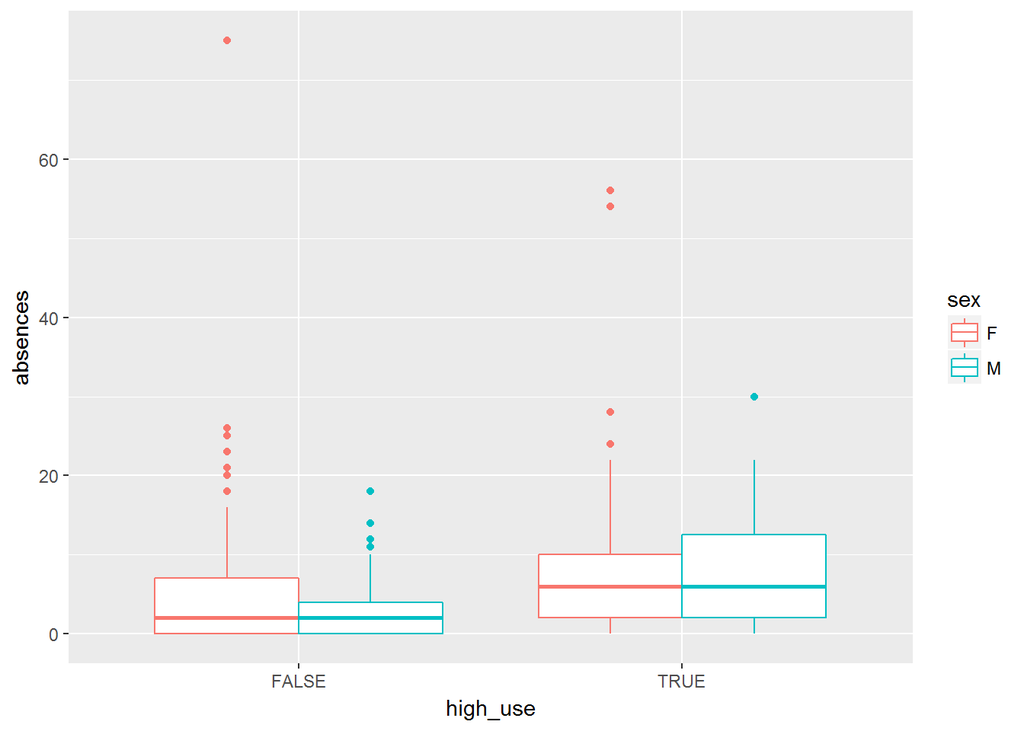

```r
g41 <- ggplot(url, aes(x = high_use, y = absences, col = sex))
g41 + geom_boxplot() + ylab("absences")
```

```r
b <- glm(high_use ~ absences, data = url)
summary(b)
```

```
##
## Call:
## glm(formula = high_use ~ absences, data = url)
##
## Deviance Residuals:
##     Min       1Q   Median       3Q      Max
## -1.2218  -0.2756  -0.2223   0.5645   0.7777
##
## Coefficients:
##             Estimate Std. Error t value Pr(>|t|)
## (Intercept) 0.222303   0.027769   8.006 1.46e-14 ***
## absences    0.013327   0.002989   4.458 1.09e-05 ***
## ---
## Signif. codes:  0 '***' 0.001 '**' 0.01 '*' 0.05 '.' 0.1 ' ' 1
##
## (Dispersion parameter for gaussian family taken to be 0.1979679)
##
##     Null deviance: 79.162  on 381  degrees of freedom
## Residual deviance: 75.228  on 380  degrees of freedom
## AIC: 469.36
##
## Number of Fisher Scoring iterations: 2
```

Here we can explore the individuals that has a high use of alcohol and the once whom not have a high use of alcohol. We can see that the variable is statistically significant (0,000). We can also see that for every absence the intercept increases by 0,013.

We can see a slight difference between the women with high and low alcohol consumption in the difference in absences. But the biggest difference lies in the diffrence between absence with high and low use of alcohol between men. In the low use (FALSE) half of the men are distributed between 0 and less than 5 absences on average. On the other hand, in the high use(TRUE) we can see that half of this group has half of their distributions between 3 and 13 absences on average.

*hypothesis* The hypothesis that the higher amount of absences the higher is the alcohol consumption. So in this distribution we can witness a slight difference between the group of low alcohol use (left side) and the group with high alcohol use (right side). From these boxplots we can see that high useers of alcohol actually has more absences in school. In other words, the hypothesis was confirmed. But I though there would have been a stronger relationship between the two variables.

### high_use vs failures

```r
high_use <-url$high_use
alc_use <-url$alc_use
```

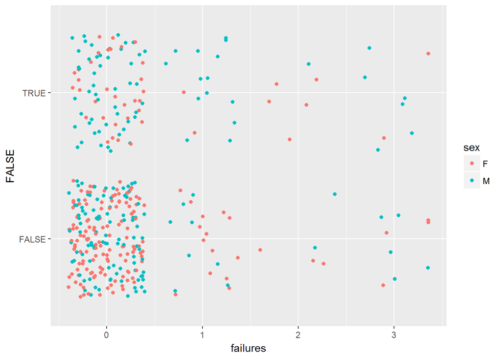

```r
g31 <- ggplot(data = url, aes(x = failures, y = high_use, col = sex))
g31 + geom_jitter() + ylab(high_use)
```

```r
m <- glm(high_use ~ failures, data = url)
summary(m)
```

```
##
## Call:
## glm(formula = high_use ~ failures, data = url)
##
## Deviance Residuals:
##     Min       1Q   Median       3Q      Max
## -0.5532  -0.2653  -0.2653   0.6387   0.7347
##
## Coefficients:
##             Estimate Std. Error t value Pr(>|t|)
## (Intercept)  0.26531    0.02484   10.68  < 2e-16 ***
## failures     0.09596    0.03167    3.03  0.00262 **
## ---
## Signif. codes:  0 '***' 0.001 '**' 0.01 '*' 0.05 '.' 0.1 ' ' 1
##
## (Dispersion parameter for gaussian family taken to be 0.2034088)
##
##     Null deviance: 79.162  on 381  degrees of freedom
## Residual deviance: 77.295  on 380  degrees of freedom
## AIC: 479.71
##
## Number of Fisher Scoring iterations: 2
```

```r
coef(m)
```

```
## (Intercept)    failures
##  0.26531008  0.09595992
```

From this output, we can find that for every more failure, the alcohol consumption will increace by 0,096.

*hypothesis* My hypothesis regarding the amount of failures would signifiantly correlate with high alcohol use, is not as clear as I had hoped for. According to the summary of the regression model it is significant, but how many times you fail a class has a very small inpact on the high alcohol use.

### High_use vs. famrel

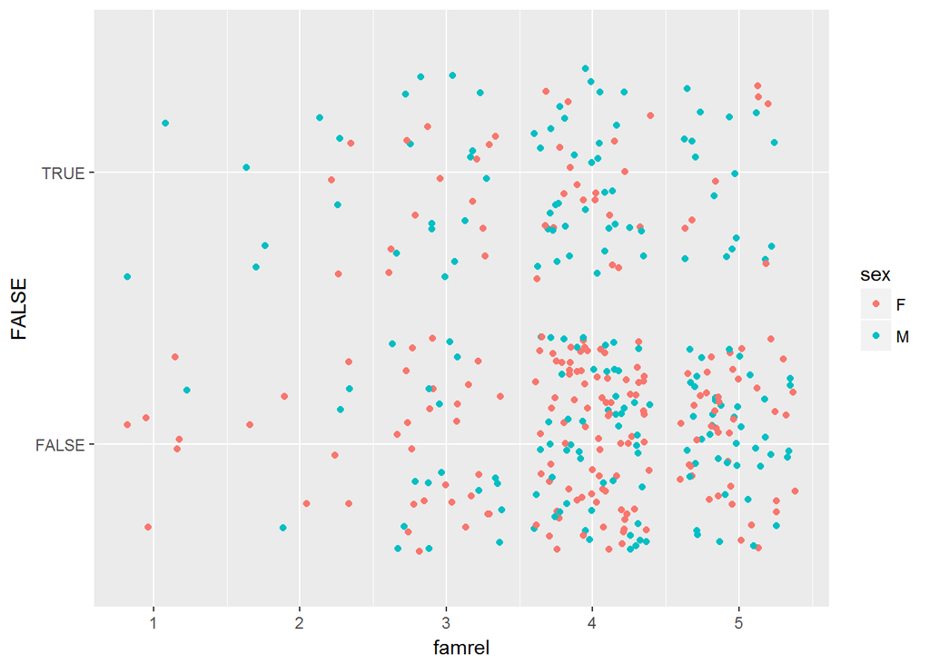

```r
g51 <- ggplot(data = url, aes(x = famrel, y = high_use, col = sex))
g51 + geom_jitter() + ylab(high_use)
```

```r
n <- glm(high_use ~ famrel, data = url)
summary(n)
```

```
##
## Call:
## glm(formula = high_use ~ famrel, data = url)
##
## Deviance Residuals:
##     Min       1Q   Median       3Q      Max
## -0.4772  -0.2894  -0.2268   0.6480   0.7732
##
## Coefficients:
##             Estimate Std. Error t value Pr(>|t|)
## (Intercept)  0.53980    0.10183   5.301 1.96e-07 ***
## famrel      -0.06259    0.02517  -2.487   0.0133 *
## ---
## Signif. codes:  0 '***' 0.001 '**' 0.01 '*' 0.05 '.' 0.1 ' ' 1
##
## (Dispersion parameter for gaussian family taken to be 0.2049851)
##
##     Null deviance: 79.162  on 381  degrees of freedom
## Residual deviance: 77.894  on 380  degrees of freedom
## AIC: 482.66
##
## Number of Fisher Scoring iterations: 2
```

```r
coef(n)
```

```
## (Intercept)      famrel
##  0.53980311 -0.06259454
```

From the output we can find that for every one step on the famrel scale, the alcohol use reduces by 0,06. This is also what my hypothesis claimed.

*hypothesis* Again my hypothesis in confirmed, but I am still not very pleased. This variable (famrel) is statistically significant, but the difference it makes is very small. I thought there would have been a bigger impact on alcohol use and bad family relationships.

### High_use vs goout

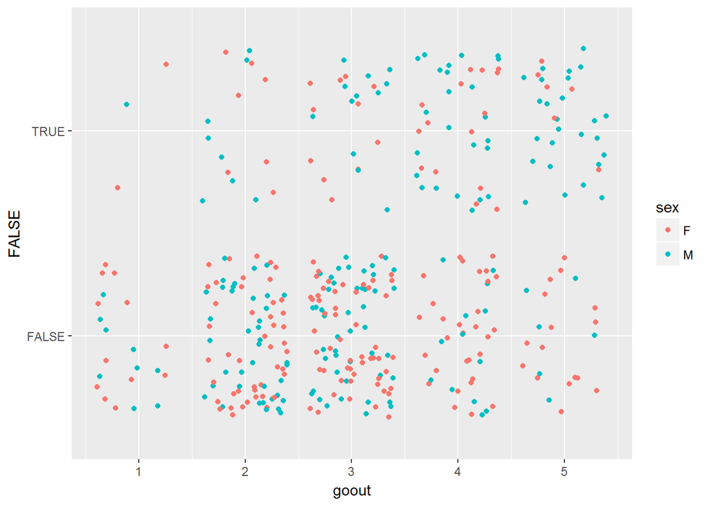

```r
g61 <- ggplot(data = url, aes(x = goout, y = high_use, col = sex))
g61 + geom_jitter() + ylab(high_use)
```

```r
e <- glm(high_use ~ goout, data = url)
summary(e)
```

```
##
## Call:
## glm(formula = high_use ~ goout, data = url)
##
## Deviance Residuals:
##     Min       1Q   Median       3Q      Max
## -0.5615  -0.2772  -0.1350   0.4385   1.0071
##
## Coefficients:
##             Estimate Std. Error t value Pr(>|t|)
## (Intercept) -0.14926    0.06400  -2.332   0.0202 *
## goout        0.14215    0.01933   7.355 1.19e-12 ***
## ---
## Signif. codes:  0 '***' 0.001 '**' 0.01 '*' 0.05 '.' 0.1 ' ' 1
##
## (Dispersion parameter for gaussian family taken to be 0.1823632)
##
##     Null deviance: 79.162  on 381  degrees of freedom
## Residual deviance: 69.298  on 380  degrees of freedom
## AIC: 437.99
##
## Number of Fisher Scoring iterations: 2
```

*hypothesis* My hypothesis was once again confirmed, and there is a statistically significant relationship between the two variables. The impact of going out with friend is bigger than all the other explanatory variables, so I am pleased with the results. This confirms that going out more could increace the alcohol consumption.

## Multiple logistic regression

But, just because every variable is individually significant with the high alcohol use variable, doens’t mean it is statistically significant if we test them all together at once.

```r
f <- glm(high_use ~ failures + absences + goout + famrel, data = url, family = "binomial")
```

```r
summary(f)
```

```
##
## Call:
## glm(formula = high_use ~ failures + absences + goout + famrel,
##     family = "binomial", data = url)
##
## Deviance Residuals:
##     Min       1Q   Median       3Q      Max
## -1.8167  -0.7339  -0.5133   0.8438   2.5091
##
## Coefficients:
##             Estimate Std. Error z value Pr(>|z|)
## (Intercept) -2.31558    0.62610  -3.698 0.000217 ***
## failures     0.28745    0.16289   1.765 0.077619 .
## absences     0.05678    0.01609   3.529 0.000417 ***
## goout        0.76620    0.12164   6.299 2.99e-10 ***
## famrel      -0.38865    0.13585  -2.861 0.004225 **
## ---
## Signif. codes:  0 '***' 0.001 '**' 0.01 '*' 0.05 '.' 0.1 ' ' 1
##
## (Dispersion parameter for binomial family taken to be 1)
##
##     Null deviance: 462.21  on 381  degrees of freedom
## Residual deviance: 385.20  on 377  degrees of freedom
## AIC: 395.2
##
## Number of Fisher Scoring iterations: 4
```

Failures is not any longer statistically significant with the target variable high_use, so I shall remove the failure variable from the logistic regression. This means that I shall run the logistic regression again, but without the failures variable.

```r
f2 <- glm(high_use ~ + absences + goout + famrel, data = url, family = "binomial")
```

```r
summary(f2)
```

```
##
## Call:
## glm(formula = high_use ~ +absences + goout + famrel, family = "binomial",
##     data = url)
##
## Deviance Residuals:
##     Min       1Q   Median       3Q      Max
## -1.8808  -0.7599  -0.5297   0.8415   2.5030
##
## Coefficients:
##             Estimate Std. Error z value Pr(>|z|)
## (Intercept) -2.28530    0.62653  -3.648 0.000265 ***
## absences     0.05691    0.01614   3.526 0.000422 ***
## goout        0.79744    0.12153   6.562 5.33e-11 ***
## famrel      -0.40001    0.13505  -2.962 0.003057 **
## ---
## Signif. codes:  0 '***' 0.001 '**' 0.01 '*' 0.05 '.' 0.1 ' ' 1
##
## (Dispersion parameter for binomial family taken to be 1)
##
##     Null deviance: 462.21  on 381  degrees of freedom
## Residual deviance: 388.31  on 378  degrees of freedom
## AIC: 396.31
##
## Number of Fisher Scoring iterations: 4
```

Now all the explanatory variables are statistically significant, so we can start to explore the odds ratios and the confidence intervalls for this model.

#### Odds ratios

```r
OR <- coef(f2) %>% exp()
```

#### Confidence intervalls

```r
CI <- confint(f2) %>% exp()
```

#### The odds ratios with their confidence intervalls

```r
cbind(OR, CI)
```

```
##                    OR      2.5 %    97.5 %
## (Intercept) 0.1017440 0.02880525 0.3385210
## absences    1.0585652 1.02737360 1.0957362
## goout       2.2198616 1.76075036 2.8384958
## famrel      0.6703131 0.51265117 0.8721354
```

To interpet these confidence intervalls and odds ratios:

The CI deifnes the upper- and lower confidence intrervalls. This means that between which values are 95% of the variable values. For example the variable goout is 95% distributed between the values 1.76 and 2.84. In this case the alpha value is 0,05, which leads to why we begin to look at the values from 2,5% and end at 97,5%.

The OR (odds ratio) explains how likley it is for a specific variable to appear. The odds ratio ranges from >0 to infinity. To exemplify this statement, we can look at the goout variable. The goout variables odds ratio is 2,22, which means, that it is a little over 2 times more likley to happened.

## Tabulation, binary prediction

Here I shall present the statistically significant explanatory variables and how to make binary predictions.

The first step I am making is creating a new variable, that consists of the function glm, in other words is to fit the logistic regression with the target variable (high_use) and explanatory variables (absences, goout, famrel).

```r
f2 <- glm(high_use ~ absences + goout + famrel, data = url, family = "binomial")
```

##### predicting

Here we use the predict function on the new variable (f2), and these values shall become a new value called probabilities.

```r
probabilities <- predict(f2, type = "response")
```

The next step that we are making, is adding the new predicted propabilities (f2) to the data we are using (url).

```r
url <- mutate(url, probability = probabilities)
```

Now we are using the new propabilities, and we shall predict the values of our target variable high_use.

```r
url <- mutate(url, prediction = probability > 0.5)
```

In this phase we want to present a table of all the target variables and the predictions of the target variables and look how they are distributed.

```r
table(high_use = url$high_use, prediction = url$prediction)
```

```
##         prediction
## high_use FALSE TRUE
##    FALSE   249   21
##    TRUE     67   45
```

Here we can se on the horizontal line we hade the high_use distribution between the distribution of FALSE and TRUE. Anf on the vertical line we can se how the predictions of high_use are distributed between FALSE and TRUE.

Next I wanted to make this plot to visualize the distribution of the probability and high_use, and defining the colors as predictions. The red color in the predictions means FALSE, and the blue color means TRUE.

```r
t <- ggplot(url, aes(x = probability, y = high_use, col = prediction))
```

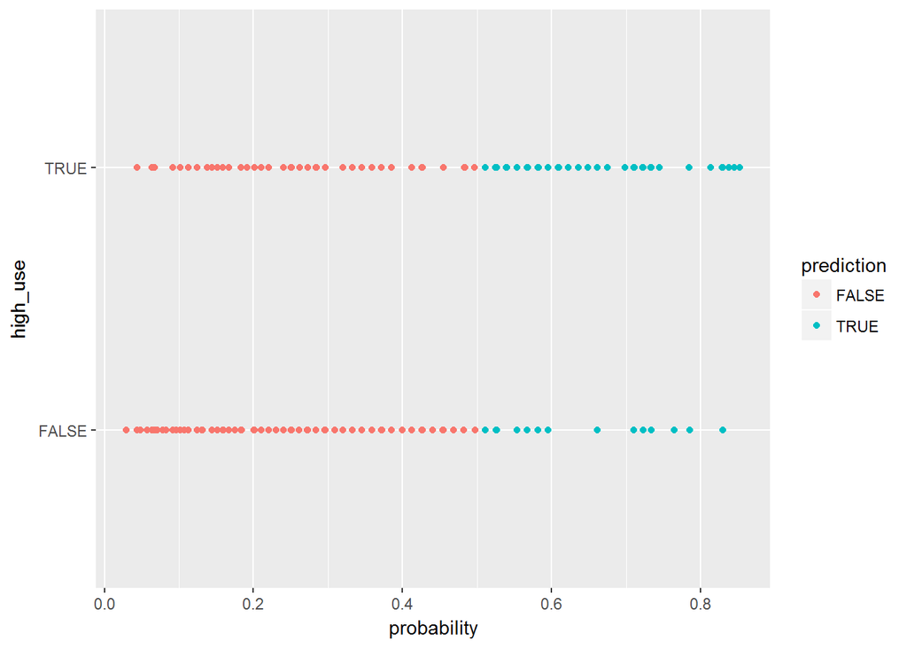

```r
t + geom_point()
```

Now when we have vizuals of the distributions of the probabilities and high_use, I still want to create a new table, that compares the target variables and probabilities in procent format.

```r
table(high_use = url$high_use, prediction = url$prediction) %>% prop.table %>% addmargins
```

```
##         prediction
## high_use      FALSE       TRUE        Sum
##    FALSE 0.65183246 0.05497382 0.70680628
##    TRUE  0.17539267 0.11780105 0.29319372
##    Sum   0.82722513 0.17277487 1.00000000
```

#### Inaccuracy

*loss_func <- function(class, prob) {* *n_wrong <- url(class - prob) > 0.5* *mean(n_wrong)* *}*

After this step I need to use this new variable loss_func, and use it to measure the mean value of the wrong preditions. This is done by using the loss function to classify the data into high_use, and use the probabilities of the url variable propability.

*loss_func(class, prob)*

This code does only give me error, and it seems the fault is found in the definign of the loss_func variable, but I don’t know how to fix it. So sadly I can’t run the two last codes due to not being able to find the error in the loss_func code.